# Final Project Report

Hunter Fristick

Due: 12/15/2021

# Set Up

### Clean up environment and load packages

```r
# clean up the RStudio environment
rm(list = ls())

# load all packages here:
library(mosaic)
library(tidyr)
library(rvest)
```

### Research Question

Does the total amount of money paid in salaries for each MLB team relate to the amount of wins a team has?

### Data Access

```r
github <- "https://raw.githubusercontent.com/stat184-sec2/final-project-report-fristick/3376afb6845ae5e503dbd7819b94db43237ccdc8/Salaries.csv"
Salaries <- readr::read_csv(github)
```

The data is from: (http://www.seanlahman.com/baseball-archive/statistics). This data set contains all of the MLB baseball statistics since 1871. It is from the Lahman’s Baseball Database. The data was collected by Ted Turocy so that we can better understand baseball statistics and is updated yearly. Key variables: year, teamID, playerID, lgID, salary

```r
web_page <- "https://www.baseball-reference.com/leagues/NL/#teams_team_wins3000"
SetOfTables <- web_page %>%
  read_html() %>%
  html_nodes(css = "table") %>%
  html_table(fill = TRUE)

NLWinsandLosses <- SetOfTables[[1]]
```

```r
web_pageAL <- "https://www.baseball-reference.com/leagues/AL/#teams_team_wins3000"
SetOfTables <- web_pageAL %>%
  read_html() %>%
  html_nodes(css = "table") %>%
  html_table(fill = TRUE)

ALWinsandLosses <- SetOfTables[[1]]
```

The second and third data set is from: (https://www.baseball-reference.com/leagues/NL/) and (https://www.baseball-reference.com/leagues/AL/). They contains the wins and losses for team for each year since 1901. It was provided by Pete Palmer and Gary Gillette of Hidden Game Sports yearly. Key variables: Year, G, each teams’ wins

```r
head(Salaries)
```

| yearID | teamID | lgID | playerID | salary |
| --- | --- | --- | --- | --- |
| 1985 | ATL | NL | barkele01 | 870000 |
| 1985 | ATL | NL | bedrost01 | 550000 |
| 1985 | ATL | NL | benedbr01 | 545000 |
| 1985 | ATL | NL | campri01 | 633333 |
| 1985 | ATL | NL | ceronri01 | 625000 |
| 1985 | ATL | NL | chambch01 | 800000 |

This shows the first 6 cases in the Salaries data set.

```r
head(NLWinsandLosses)
```

| Year | G | ARI | ATL | CHC | CIN | COL | HOU | LAD | MIA | MIL | NYM | PHI | PIT | SDP | SFG | STL | WSN |
| --- | --- | --- | --- | --- | --- | --- | --- | --- | --- | --- | --- | --- | --- | --- | --- | --- | --- |
| 2021 | 162 | 52 | 88 | 71 | 83 | 74 |  | 106 | 67 | 95 | 77 | 82 | 61 | 79 | 107 | 90 | 65 |
| 2020 | 60 | 25 | 35 | 34 | 31 | 26 |  | 43 | 31 | 29 | 26 | 28 | 19 | 37 | 29 | 30 | 26 |
| 2019 | 162 | 85 | 97 | 84 | 75 | 71 |  | 106 | 57 | 89 | 86 | 81 | 69 | 70 | 77 | 91 | 93 |
| 2018 | 163 | 82 | 90 | 95 | 67 | 91 |  | 92 | 63 | 96 | 77 | 80 | 82 | 66 | 73 | 88 | 82 |
| 2017 | 162 | 93 | 72 | 92 | 68 | 87 |  | 104 | 77 | 86 | 70 | 66 | 75 | 71 | 64 | 83 | 97 |
| 2016 | 162 | 69 | 68 | 103 | 68 | 75 |  | 91 | 79 | 73 | 87 | 71 | 78 | 68 | 87 | 86 | 95 |

This shows the first 6 cases in the NL Wins and Loses data set.

```r
summary(ALWinsandLosses)
```

```
     Year                G                 BAL                BLA                BOS                CHW                CLE
 Length:125         Length:125         Length:125         Length:125         Length:125         Length:125         Length:125
 Class :character   Class :character   Class :character   Class :character   Class :character   Class :character   Class :character
 Mode  :character   Mode  :character   Mode  :character   Mode  :character   Mode  :character   Mode  :character   Mode  :character
     DET                HOU                KCR                LAA                MIL                MIN                NYY
 Length:125         Length:125         Length:125         Length:125         Length:125         Length:125         Length:125
 Class :character   Class :character   Class :character   Class :character   Class :character   Class :character   Class :character
 Mode  :character   Mode  :character   Mode  :character   Mode  :character   Mode  :character   Mode  :character   Mode  :character
     OAK                SEA                TBR                TEX                TOR
 Length:125         Length:125         Length:125         Length:125         Length:125
 Class :character   Class :character   Class :character   Class :character   Class :character
 Mode  :character   Mode  :character   Mode  :character   Mode  :character   Mode  :character
```

This is a summary of the AL Wins and Losses and all of the data is a character class.

```r
summary(Salaries)
```

```
     yearID        teamID              lgID             playerID             salary
 Min.   :1985   Length:26428       Length:26428       Length:26428       Min.   :       0
 1st Qu.:1994   Class :character   Class :character   Class :character   1st Qu.:  294702
 Median :2001   Mode  :character   Mode  :character   Mode  :character   Median :  550000
 Mean   :2001                                                            Mean   : 2085634
 3rd Qu.:2009                                                            3rd Qu.: 2350000
 Max.   :2016                                                            Max.   :33000000
```

This shows a summary of the Salaries and the mean salary for a player is $2,085,634 per year.

### Data Wrangling / Cleaning

```r
 NLWinsLonger <-
    NLWinsandLosses %>%
    pivot_longer(cols = c(ARI, ATL, CHC, CIN, COL, HOU, LAD, MIA, MIL, NYM, PHI, PIT, SDP, SFG, STL, WSN), names_to = "Team", values_to = "Wins")

ALWinsLonger <-
    ALWinsandLosses %>%
    pivot_longer(cols = c(BAL, BLA, BOS, CHW, CLE, DET, HOU, KCR, LAA, MIL, MIN, NYY, OAK, SEA, TBR, TEX, TOR), names_to = "Team", values_to = "Wins")
WinsLonger <- rbind(NLWinsLonger, ALWinsLonger)
```

In this step I am pivoting both NLWinsandLosses and ALWinsandLosses into a narrow form. Then I am binding both tables together so that I can use them as one table. I need to pivot them to make the data easier to use and graph later on in the project.

```r
SalSum <-
  Salaries %>%
  group_by(yearID = as.character(yearID), teamID) %>%
  summarise(totalSal = sum(salary))
SalSum
```

| yearID | teamID | totalSal |
| --- | --- | --- |
| 1985 | ATL | 14807000 |
| 1985 | BAL | 11560712 |
| 1985 | BOS | 10897560 |
| 1985 | CAL | 14427894 |
| 1985 | CHA | 9846178 |
| 1985 | CHN | 12702917 |
| 1985 | CIN | 8359917 |
| 1985 | CLE | 6551666 |
| 1985 | DET | 10348143 |
| 1985 | HOU | 9993051 |

[output cut: 908 more lines]

In this query I am grouping the salaries by year and the team. Then I am summing the salaries so that I have a yearly total for each team overall. This allows me to able to compare each team to each other by how much they pay out in salaries per year. For example, in 1985, ATL paid out more in salaries than BOS did.

```r
JoinedData <-
  SalSum %>%
  inner_join(WinsLonger, by = c("yearID" = "Year", "teamID" = "Team")) %>%
  group_by(yearID = as.double(yearID)) %>%
  mutate(Wins = as.double(Wins)) %>%
  na_if('') %>%
  drop_na()

JoinedData
```

| yearID | teamID | totalSal | G | Wins |
| --- | --- | --- | --- | --- |
| 1985 | ATL | 14807000 | 162 | 66 |
| 1985 | BAL | 11560712 | 162 | 83 |
| 1985 | BOS | 10897560 | 162 | 81 |
| 1985 | CIN | 8359917 | 162 | 89 |
| 1985 | CLE | 6551666 | 162 | 60 |
| 1985 | DET | 10348143 | 162 | 84 |
| 1985 | HOU | 9993051 | 162 | 83 |
| 1985 | MIN | 5764821 | 162 | 77 |
| 1985 | OAK | 9058606 | 162 | 77 |
| 1985 | PHI | 10124966 | 162 | 75 |

[output cut: 517 more lines]

In this query I am joining the SalSum data with the WinsLonger data. This will allow me to analyze the salaries based on how many wins each team has throughout the years. I joined the data based on matching year and team name and I used an inner join to ensure that only the data that matched was selected. Since some teams switch from NL to Al in later years, I had to remove any repeated N/A values where they no longer had any data in one of the tables. This cleaned up the data set so that every case has a number to go with it.

```r
AvgSal <-
  JoinedData %>%
   group_by(yearID = as.double(yearID)) %>%
  summarise(avgSal = mean(totalSal))

AvgSal
```

| yearID | avgSal |
| --- | --- |
| 1985 | 9128285 |
| 1986 | 10907492 |
| 1987 | 9570220 |
| 1988 | 10717997 |
| 1989 | 12830917 |
| 1990 | 15569871 |
| 1991 | 22287351 |
| 1992 | 29681354 |
| 1993 | 32383790 |
| 1994 | 34671170 |

[output cut: 22 more lines]

This query shows the average salary of all teams combined for each year in the data from 1985 to 2016. I grouped the data by year and took the mean of it to get the table above. As the years go on, you can see that the average salary increased which is probably because of baseball becoming more popular, as well as inflation.

```r
Total90s <-
  JoinedData %>%
  filter(grepl('..0.', yearID, ignore.case = TRUE)) %>%
  summarise(avgWins = mean(Wins), GamesPlayed = G)
Total90s
```

| yearID | avgWins | GamesPlayed |
| --- | --- | --- |
| 2000 | 79.94118 | 162 |
| 2000 | 79.94118 | 162 |
| 2000 | 79.94118 | 162 |
| 2000 | 79.94118 | 162 |
| 2000 | 79.94118 | 162 |
| 2000 | 79.94118 | 162 |
| 2000 | 79.94118 | 162 |
| 2000 | 79.94118 | 162 |
| 2000 | 79.94118 | 162 |
| 2000 | 79.94118 | 162 |

[output cut: 165 more lines]

This query uses a regular expression to to grab all of the years in the data who are included in the 2000s. This is done by filtering the data to only include years with a 0 in the third place. I then summarized the average amount of Wins for each year. The Avg amount of Wins stayed between 79 and 82 while the amount of Games Played did not change and stayed at 162.

```r
DifinHighLow <-
  JoinedData %>%
  group_by(yearID) %>%
  mutate(SalDifference = max(totalSal) - min(totalSal)) %>%
  mutate(WinDifference = max(Wins) - min(Wins)) %>%
  summarise(yearID, SalDifference, WinDifference, G) %>%
  unique()
TwoYears <-
  DifinHighLow %>%
  filter(yearID == 1985 | yearID == 2016)

TwoYears
```

| yearID | SalDifference | WinDifference | G |
| --- | --- | --- | --- |
| 1985 | 10194000 | 42 | 162 |
| 2016 | 135896481 | 36 | 162 |

This query shows how the total difference in salaries per team has increased over the years. In 1985 there was $10,194,000 difference between the highest and lowest salary and in 2016 there was $135,896,481. So as the years increase, the gap between the lowest and highest salary has increased tremendously. The difference in highest and lowest wins however, went down, which is interesting to see.

### Data Visualization

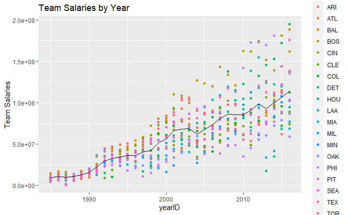

```r
JoinedDataAvg <-
  ggplot() +
  geom_point(data = JoinedData, aes(x = yearID, y = totalSal, color = teamID)) +
  geom_line(data = AvgSal, aes(x = yearID, y = avgSal)) +
  ylab('Team Salaries') +
  ggtitle('Team Salaries by Year')

JoinedDataAvg
```

This graphic shows the team salaries based on the year. The line on the graph is the avg salary for each team by year each color represents a different team on the graphic. For example, the team with the highest salary overall is the green dot in the upper right corner. From looking at this image, you can see that salaries have increased overtime. This is because as baseball has gotten more popular, more money has been put into the sport. What this also shows is as the years go on, there is a larger difference between the smallest and largest salary. In the first few years the teams spent around the same amount on salaries, but in 2016 there is a large difference in how much each team spent.

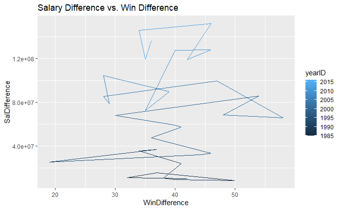

```r
DifinHighLow %>%
  ggplot(aes(x = WinDifference, y = SalDifference, color = yearID)) +
  geom_path() +
  ggtitle('Salary Difference vs. Win Difference')
```

### Conclusion

In conclusion, the amount of money spent on salary does not seem to affect the amount of wins a team gets. It seemed to have more of an effect from the 90s to 2000s. After that, the increase in salaries is not affecting the amount of wins a team gets since the difference from most to least wins stays around the same numbers. The salary increase must be affected by another outside source not related to wins, like inflation or the sport becoming popular. These factors could not be measured from this data that I used. One significant challenge I had while using this data set was trying to figure how to pivot the NL and AL data set to make it easy to run queries on. After looking in the textbook, I was eventually able to figure it out which helped tremendously with my analysis.